# Analysis of Used Cars Dataset

Farooq A. Khan

30/07/2020

## The dataset

There are 13 cars datasets that have been defined below:

```r
companies<-c('audi', 'bmw', 'cclass', 'focus', 'ford', 'hyundi', 'merc', 'skoda', 'toyota', 'unclean cclass', 'unclean focus', 'vauxhall', 'vw')
```

## Analyze Toyota

```r
toyota <- read.csv('../data/toyota.csv')
```

Here is the dataset:

```r
library(knitr)
kable(toyota[1:5,], caption="First Five Rows of Toyota dataset")
```

First Five Rows of Toyota dataset

| model | year | price | transmission | mileage | fuelType | tax | mpg | engineSize |
| --- | --- | --- | --- | --- | --- | --- | --- | --- |
| GT86 | 2016 | 16000 | Manual | 24089 | Petrol | 265 | 36.2 | 2 |
| GT86 | 2017 | 15995 | Manual | 18615 | Petrol | 145 | 36.2 | 2 |
| GT86 | 2015 | 13998 | Manual | 27469 | Petrol | 265 | 36.2 | 2 |
| GT86 | 2017 | 18998 | Manual | 14736 | Petrol | 150 | 36.2 | 2 |
| GT86 | 2017 | 17498 | Manual | 36284 | Petrol | 145 | 36.2 | 2 |

Here are some unique models of Toyota cars:

```r
kable(unique(toyota[,'model']), caption="Unique models of Toyota Cars")
```

Unique models of Toyota Cars

| x |
| --- |
| GT86 |
| Corolla |
| RAV4 |
| Yaris |
| Auris |
| Aygo |
| C-HR |
| Prius |
| Avensis |
| Verso |
| Hilux |
| PROACE VERSO |
| Land Cruiser |
| Supra |
| Camry |
| Verso-S |
| IQ |
| Urban Cruiser |

Here is also unique fuel types.

```r
kable(unique(toyota[,'fuelType']), caption="Unique fuel types of Toyota Cars")
```

Unique fuel types of Toyota Cars

| x |
| --- |
| Petrol |
| Other |
| Hybrid |
| Diesel |

### Graphical Analysis

Below we graph the mileage to price scatter plot and group the cars based on Fuel Type. As you can see the cheapest cars are those with “Petrol” as a fuel Type.

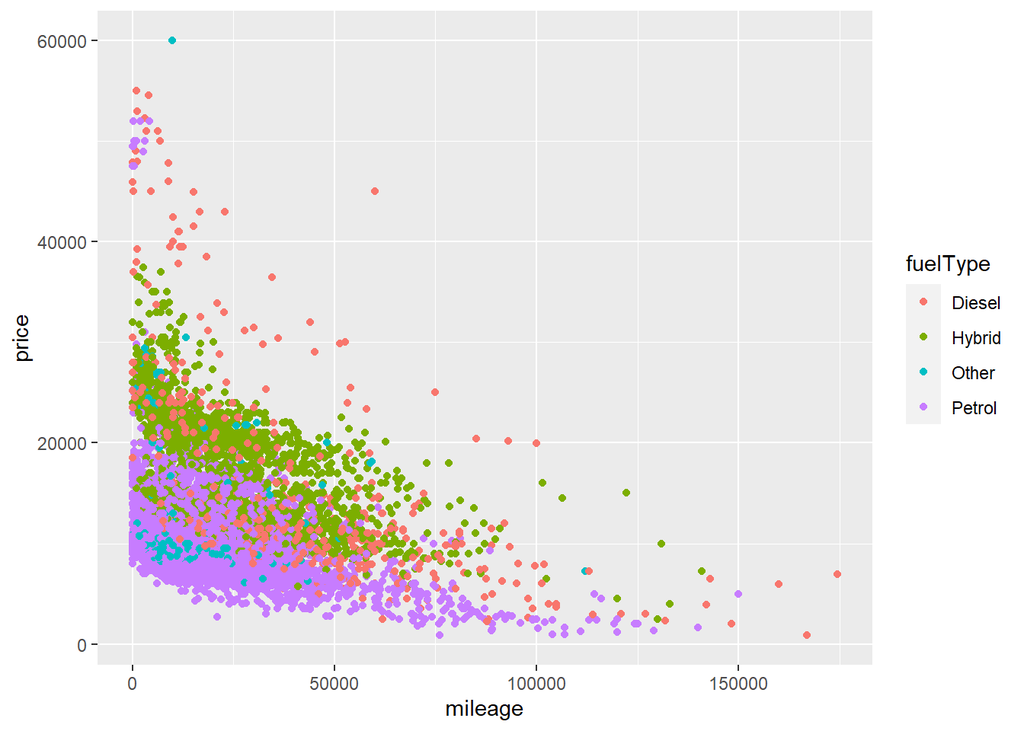

```r
library(ggplot2)
ggplot(toyota, aes(mileage, price, colour=fuelType)) +
  geom_point()
```

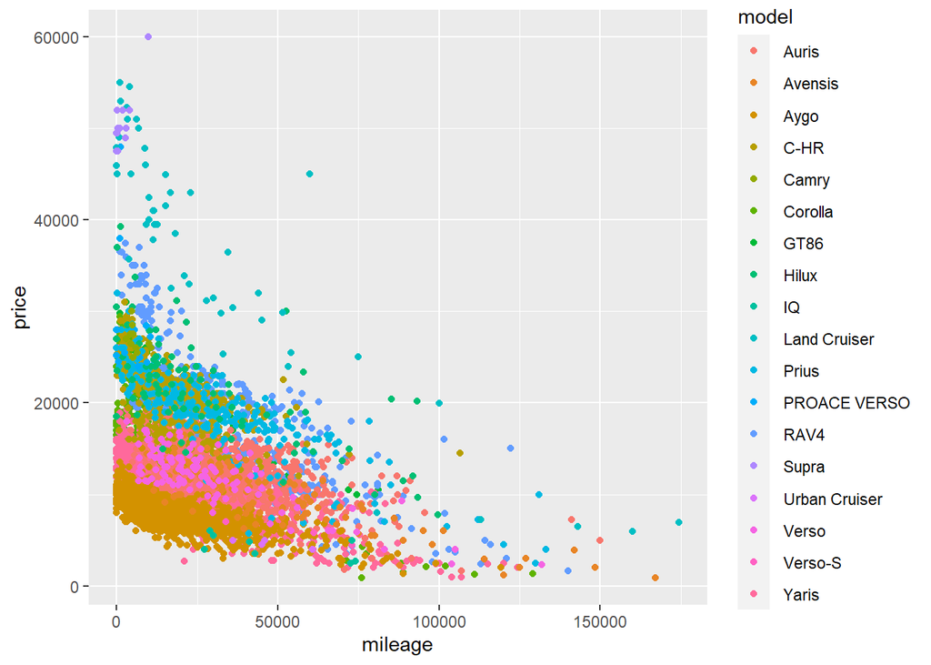

```r
ggplot(toyota, aes(mileage, price, colour=model)) + geom_point()
```

Below you can see that there are alot of toyota cars that run on petrol.

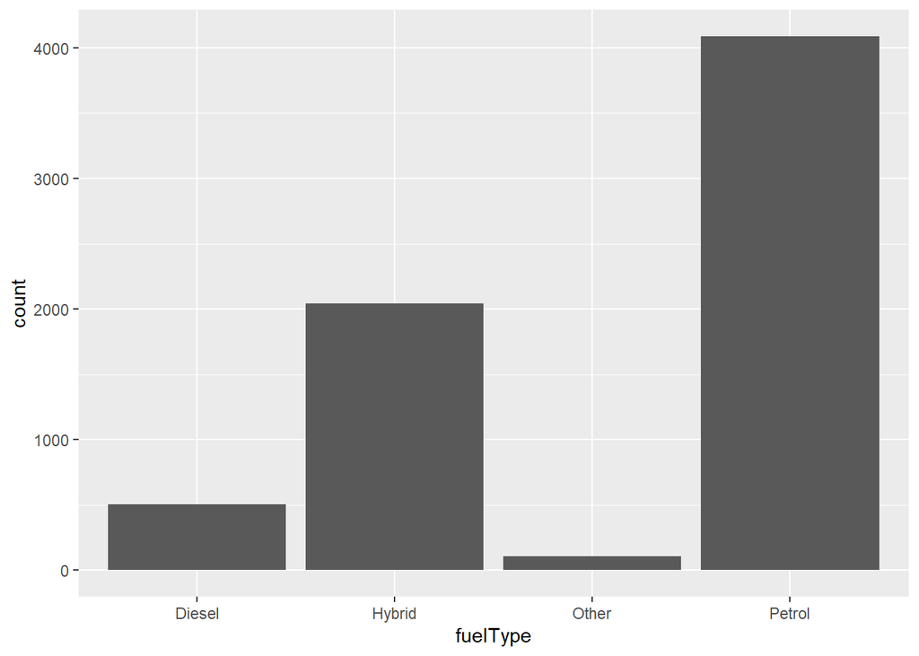

```r
ggplot(toyota) + geom_bar(aes(x=fuelType))
```

The two most common types of cars are Aygo and Yaris.

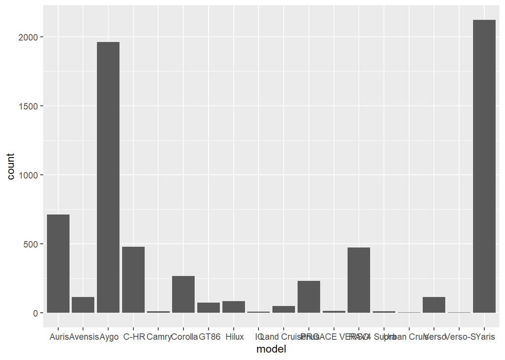

```r
ggplot(toyota) + geom_bar(aes(x=model))
```

Lets compare engine size to price. Small engine sizes yield cheaper prices with higher mileage.

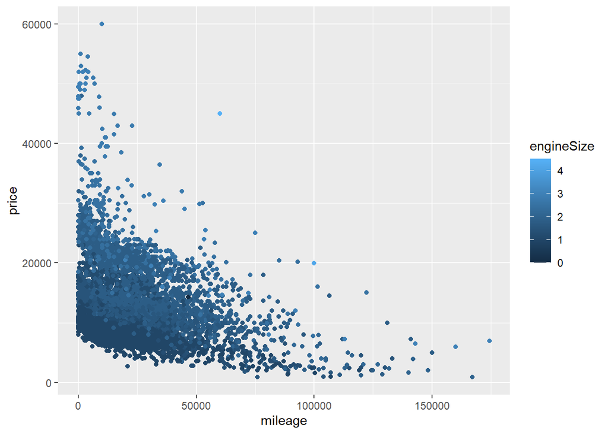

```r
ggplot(toyota, aes(mileage, price, colour=engineSize)) + geom_point()
```

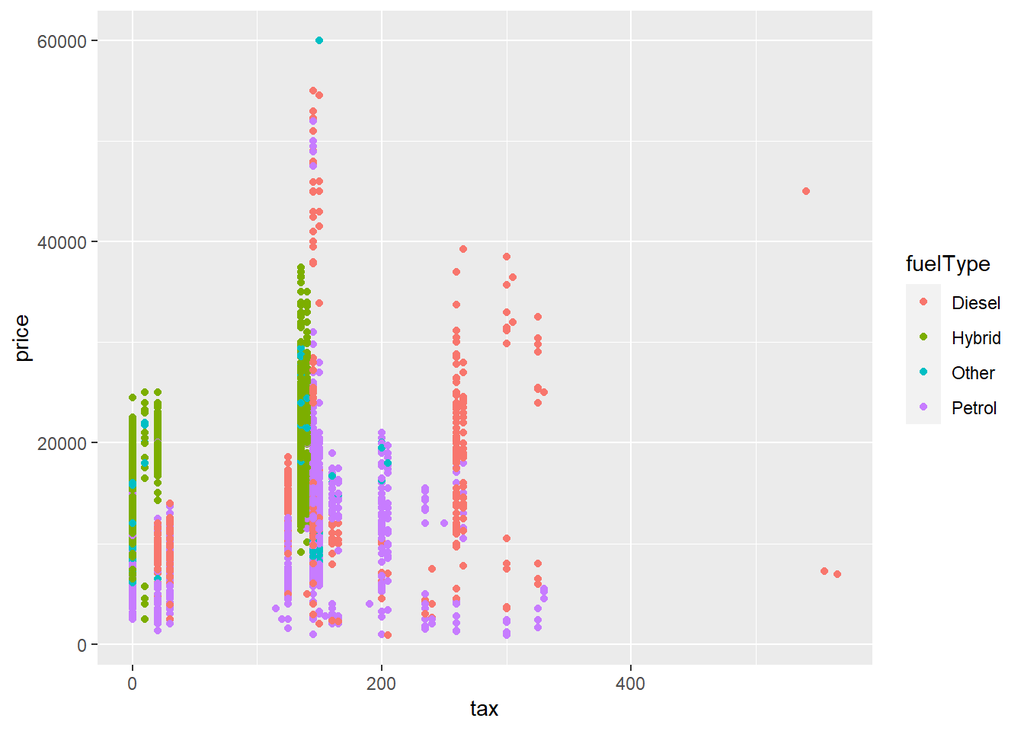

```r
ggplot(toyota, aes(tax, price, colour=fuelType)) + geom_point()
```

Tax appears to be a finite set of values and not a part of the real plane. Also the hypothese is that cars that are not eco friendly will be taxed more.

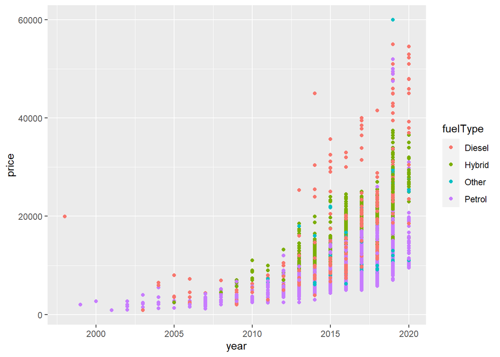

```r
ggplot(toyota, aes(year, price, colour=fuelType)) + geom_point()
```

## Linear COrrelation

```r
cor(toyota$mileage, toyota$price)
```

```
## [1] -0.2979358
```

There is negative weak correlation between mileage and price.

```r
cor(toyota$tax, toyota$price)
```

```
## [1] 0.2144983
```

There is also weak correlation between tax and price.

## Forming Linear Models

```r
model <- lm(formula=price ~ year + mileage + tax + mpg + engineSize, data=toyota)
summary(model)
```

```
##
## Call:
## lm(formula = price ~ year + mileage + tax + mpg + engineSize,
##     data = toyota)
##
## Residuals:
##      Min       1Q   Median       3Q      Max
## -11680.6  -1865.3   -407.8   1143.2  27646.7
##
## Coefficients:
##               Estimate Std. Error t value Pr(>|t|)
## (Intercept) -1.688e+06  5.178e+04 -32.607  < 2e-16 ***
## year         8.353e+02  2.567e+01  32.534  < 2e-16 ***
## mileage     -7.874e-02  2.943e-03 -26.752  < 2e-16 ***
## tax         -1.418e+00  5.979e-01  -2.373   0.0177 *
## mpg          2.176e+01  2.653e+00   8.201 2.83e-16 ***
## engineSize   1.153e+04  8.996e+01 128.167  < 2e-16 ***
## ---
## Signif. codes:  0 '***' 0.001 '**' 0.01 '*' 0.05 '.' 0.1 ' ' 1
##
## Residual standard error: 3085 on 6732 degrees of freedom
## Multiple R-squared:  0.7638, Adjusted R-squared:  0.7636
## F-statistic:  4353 on 5 and 6732 DF,  p-value: < 2.2e-16
```

The R-suqred and adjusted R-squared value is 0.764 showing positive moderate correlation.

Lets try it wihtout tax this time and see the R-squared value.

```r
model2<- lm(formula=price ~ year + mileage + mpg + engineSize, data=toyota)
summary(model2)
```

```
##
## Call:
## lm(formula = price ~ year + mileage + mpg + engineSize, data = toyota)
##
## Residuals:
##    Min     1Q Median     3Q    Max
## -11809  -1829   -406   1146  27722
##
## Coefficients:
##               Estimate Std. Error t value Pr(>|t|)
## (Intercept) -1.663e+06  5.064e+04  -32.83   <2e-16 ***
## year         8.224e+02  2.510e+01   32.77   <2e-16 ***
## mileage     -7.867e-02  2.944e-03  -26.72   <2e-16 ***
## mpg          2.448e+01  2.394e+00   10.22   <2e-16 ***
## engineSize   1.150e+04  8.907e+01  129.10   <2e-16 ***
## ---
## Signif. codes:  0 '***' 0.001 '**' 0.01 '*' 0.05 '.' 0.1 ' ' 1
##
## Residual standard error: 3086 on 6733 degrees of freedom
## Multiple R-squared:  0.7636, Adjusted R-squared:  0.7634
## F-statistic:  5437 on 4 and 6733 DF,  p-value: < 2.2e-16
```

Computationally better but mathematically the same.

## Converting finite sets to numbers

```r
toyota$fuelTypeNum <- ifelse(toyota$fuelType=='Petrol', 1, ifelse(toyota$fuelType=='Other', 2,
ifelse(toyota$fuelType=='Hybrid', 3, 4)
)
)
```

This is model 3 with fuelTypeNum column in it.

```r
model3<- lm(formula=price ~ year + mileage + fuelTypeNum + mpg + engineSize, data=toyota)
summary(model3)
```

```
##
## Call:
## lm(formula = price ~ year + mileage + fuelTypeNum + mpg + engineSize,
##     data = toyota)
##
## Residuals:
##      Min       1Q   Median       3Q      Max
## -11746.2  -1866.7   -424.2   1165.6  28421.6
##
## Coefficients:
##               Estimate Std. Error t value Pr(>|t|)
## (Intercept) -1.652e+06  5.052e+04 -32.698  < 2e-16 ***
## year         8.175e+02  2.503e+01  32.656  < 2e-16 ***
## mileage     -8.113e-02  2.960e-03 -27.408  < 2e-16 ***
## fuelTypeNum  3.772e+02  5.852e+01   6.446 1.23e-10 ***
## mpg          1.491e+01  2.811e+00   5.306 1.16e-07 ***
## engineSize   1.081e+04  1.388e+02  77.884  < 2e-16 ***
## ---
## Signif. codes:  0 '***' 0.001 '**' 0.01 '*' 0.05 '.' 0.1 ' ' 1
##
## Residual standard error: 3077 on 6732 degrees of freedom
## Multiple R-squared:  0.765,  Adjusted R-squared:  0.7649
## F-statistic:  4384 on 5 and 6732 DF,  p-value: < 2.2e-16
```

The R-squared value has improved a bit as well.

### Numeric model

```r
toyota$modelNum <- ifelse(
  toyota$model==' GT86', 1, ifelse(
    toyota$model==' Corolla', 2, ifelse(
      toyota$model==' RAV4', 3, ifelse(
        toyota$model==' Yaris', 4, ifelse(
          toyota$model==' Auris', 5, ifelse(
            toyota$model==' Aygo', 6, ifelse(
              toyota$model==' C-HR', 7, ifelse(
                toyota$model==' Prius', 8, ifelse(
                  toyota$model==' Avensis', 9, ifelse(
                    toyota$model==' Verso', 10, ifelse(
                      toyota$model==' Hilux', 11, ifelse(
                        toyota$model==' PROACE VERSO', 12, ifelse(
                          toyota$model==' Land Cruiser', 13, ifelse(
                            toyota$model==' Supra', 14, ifelse(
                              toyota$model==' Camry', 15, ifelse(
                                toyota$model==' Verso-S', 16, ifelse(
                                  toyota$model==' IQ', 17, 18
                                  )
                                )
                              )
                            )
                          )
                        )
                      )
                    )
                  )
                )
              )
            )
          )
        )
      )
    )
)
```

This is model 4 with modelNum column in it.

```r
model4<- lm(formula=price ~ year + mileage + fuelTypeNum + modelNum + mpg + engineSize, data=toyota)
summary(model4)
```

```
##
## Call:
## lm(formula = price ~ year + mileage + fuelTypeNum + modelNum +
##     mpg + engineSize, data = toyota)
##
## Residuals:
##      Min       1Q   Median       3Q      Max
## -13996.2  -1729.0   -433.6   1165.4  24547.6
##
## Coefficients:
##               Estimate Std. Error t value Pr(>|t|)
## (Intercept) -1.651e+06  4.859e+04 -33.989  < 2e-16 ***
## year         8.161e+02  2.408e+01  33.895  < 2e-16 ***
## mileage     -8.262e-02  2.847e-03 -29.017  < 2e-16 ***
## fuelTypeNum  2.083e+02  5.674e+01   3.671 0.000244 ***
## modelNum     4.102e+02  1.753e+01  23.397  < 2e-16 ***
## mpg          1.853e+01  2.708e+00   6.845 8.33e-12 ***
## engineSize   1.108e+04  1.340e+02  82.693  < 2e-16 ***
## ---
## Signif. codes:  0 '***' 0.001 '**' 0.01 '*' 0.05 '.' 0.1 ' ' 1
##
## Residual standard error: 2959 on 6731 degrees of freedom
## Multiple R-squared:  0.7827, Adjusted R-squared:  0.7825
## F-statistic:  4041 on 6 and 6731 DF,  p-value: < 2.2e-16
```

We see more improvement with it now having an R squared value of .78.

### Transmission

```r
toyota$transNum <- ifelse(
  toyota$transmission=='Manual',1, ifelse(
    toyota$transmission=='Automatic',2, ifelse(
      toyota$transmission=='Semi-Auto',3, 4
    )
  )
)
```

```r
model5<- lm(formula=price ~ year + mileage + fuelTypeNum + modelNum + transNum + mpg + engineSize, data=toyota)
summary(model5)
```

```
##
## Call:
## lm(formula = price ~ year + mileage + fuelTypeNum + modelNum +
##     transNum + mpg + engineSize, data = toyota)
##
## Residuals:
##      Min       1Q   Median       3Q      Max
## -12775.8  -1745.9   -427.7   1122.9  24899.3
##
## Coefficients:
##               Estimate Std. Error t value Pr(>|t|)
## (Intercept) -1.746e+06  4.673e+04 -37.363   <2e-16 ***
## year         8.630e+02  2.316e+01  37.265   <2e-16 ***
## mileage     -7.214e-02  2.763e-03 -26.110   <2e-16 ***
## fuelTypeNum  7.813e+01  5.465e+01   1.430    0.153
## modelNum     3.788e+02  1.686e+01  22.469   <2e-16 ***
## transNum     1.783e+03  7.304e+01  24.406   <2e-16 ***
## mpg          2.281e+00  2.679e+00   0.851    0.395
## engineSize   1.014e+04  1.341e+02  75.636   <2e-16 ***
## ---
## Signif. codes:  0 '***' 0.001 '**' 0.01 '*' 0.05 '.' 0.1 ' ' 1
##
## Residual standard error: 2836 on 6730 degrees of freedom
## Multiple R-squared:  0.8004, Adjusted R-squared:  0.8002
## F-statistic:  3855 on 7 and 6730 DF,  p-value: < 2.2e-16
```

With model 5 we have r-suqared value of 0.8.

```r
model6<- lm(formula=price ~ year + mileage+ modelNum + transNum + engineSize, data=toyota)
summary(model6)
```

```
##
## Call:
## lm(formula = price ~ year + mileage + modelNum + transNum + engineSize,
##     data = toyota)
##
## Residuals:
##    Min     1Q Median     3Q    Max
## -12838  -1748   -413   1125  24666
##
## Coefficients:
##               Estimate Std. Error t value Pr(>|t|)
## (Intercept) -1.753e+06  4.663e+04  -37.60   <2e-16 ***
## year         8.666e+02  2.311e+01   37.50   <2e-16 ***
## mileage     -7.105e-02  2.720e-03  -26.12   <2e-16 ***
## modelNum     3.811e+02  1.674e+01   22.77   <2e-16 ***
## transNum     1.837e+03  6.836e+01   26.86   <2e-16 ***
## engineSize   1.023e+04  9.139e+01  111.96   <2e-16 ***
## ---
## Signif. codes:  0 '***' 0.001 '**' 0.01 '*' 0.05 '.' 0.1 ' ' 1
##
## Residual standard error: 2837 on 6732 degrees of freedom
## Multiple R-squared:  0.8002, Adjusted R-squared:  0.8001
## F-statistic:  5393 on 5 and 6732 DF,  p-value: < 2.2e-16
```

## Confidence Interval

```r
confint(model6, level=0.95) # CIs for model parameters
```

```
##                     2.5 %        97.5 %
## (Intercept) -1.844766e+06 -1.661930e+06
## year         8.213080e+02  9.119052e+02
## mileage     -7.637956e-02 -6.571651e-02
## modelNum     3.482421e+02  4.138659e+02
## transNum     1.702534e+03  1.970553e+03
## engineSize   1.005234e+04  1.041063e+04
```

## Anova Table

```r
anova(model6) # anova table
```

```
## Analysis of Variance Table
##
## Response: price
##              Df     Sum Sq    Mean Sq    F value Pr(>F)
## year          1 4.8063e+10 4.8063e+10  5971.3787 <2e-16 ***
## mileage       1 4.0851e+07 4.0851e+07     5.0753 0.0243 *
## modelNum      1 6.1894e+09 6.1894e+09   768.9717 <2e-16 ***
## transNum      1 6.1855e+10 6.1855e+10  7684.8780 <2e-16 ***
## engineSize    1 1.0089e+11 1.0089e+11 12534.9244 <2e-16 ***
## Residuals  6732 5.4185e+10 8.0489e+06
## ---
## Signif. codes:  0 '***' 0.001 '**' 0.01 '*' 0.05 '.' 0.1 ' ' 1
```

```r
kable(vcov(model6))# covariance matrix for model parameters
```

|  | (Intercept) | year | mileage | modelNum | transNum | engineSize |
| --- | --- | --- | --- | --- | --- | --- |
| (Intercept) | 2.174767e+09 | -1.077612e+06 | -93.0303341 | 8326.7565563 | -2.061817e+05 | 6.065031e+05 |
| year | -1.077612e+06 | 5.339703e+02 | 0.0460798 | -4.7910466 | 1.009348e+02 | -3.041575e+02 |
| mileage | -9.303033e+01 | 4.607980e-02 | 0.0000074 | -0.0022509 | 2.102020e-02 | -6.055390e-02 |
| modelNum | 8.326757e+03 | -4.791047e+00 | -0.0022509 | 280.1627608 | -1.007127e+02 | 3.723187e+01 |
| transNum | -2.061817e+05 | 1.009348e+02 | 0.0210202 | -100.7127447 | 4.673249e+03 | -2.852713e+03 |
| engineSize | 6.065031e+05 | -3.041575e+02 | -0.0605539 | 37.2318682 | -2.852713e+03 | 8.351337e+03 |

## K-fold cross-validation

https://www.statmethods.net/stats/regression.html.

```r
library(DAAG)
X <- as.matrix(toyota[c("year","mileage","fuelTypeNum", "mpg", "engineSize", "modelNum")])
# vector of predicted values
y <- as.matrix(toyota[c("price")])
#cv.lm(df=X, fit, m=3) # 3 fold cross-validation
```

```r
library(bootstrap)

fit <- model6
# define functions
theta.fit <- function(x,y){lsfit(x,y)}
theta.predict <- function(fit,x){cbind(1,x)%*%fit$coef}

results <- crossval(X,y,theta.fit,theta.predict,ngroup=10)
cor(y, fit$fitted.values)**2 # raw R2
```

```
##           [,1]
## price 0.800221
```

```r
cor(y,results$cv.fit)**2 # cross-validated R2
```

```
##           [,1]
## price 0.781844
```